# Анализ оттока клиентов банка.

**Описание проекта:** Заказчик — отдел маркетинга регионального банка. Последнее время в банке наблюдается резкий отток клиентов. Около 2 000 клиентов решили покинуть банк.

**Наша задача:** Проанализировать пользователей банковских услуг и выделить сегменты клиентов, которые склонны уйти из банка. Дать конкретные рекомендации по приоритетным сегментам. Предоставить отчёт по исследованию в виде презентации в PDF-формате.

**Описание датасета:** Нам доступен датасет с данными о клиентах банка. Банк располагается в Ярославле и областных городах: Ростов Великий и Рыбинск.

**Общий ход исследования:**

1. Загрузка данных и знакомство с ними.
2. Предобработка и подготовка данных к исследованию.
3. Исследовательский анализ данных.
4. Проверка статистических гипотез.
5. Промежуточный итог о том, какие показатели стратегически влияют на отток.
6. Сегментация на основе стратегических показателей.
7. Выводы и рекомендации (конкретные, по конкретным сегментам) для заказчика.
8. Подготовка презентации.

## Загрузим данные и изучим общую информацию.

### Загрузим данные и ознакомимся с содержанием.

|  | USERID | score | city | gender | age | equity | balance | products | credit_card | last_activity | EST_SALARY | churn |
| --- | --- | --- | --- | --- | --- | --- | --- | --- | --- | --- | --- | --- |
| 9169 | 185521 | 811.0 | Ярославль | Ж | 67.0 | 0 | NaN | 1 | 0 | 1 | 180,712.0 | 0 |
| 9390 | 135226 | 973.0 | Рыбинск | Ж | 43.0 | 3 | 478,373.9 | 1 | 1 | 1 | 116,687.3 | 0 |
| 9615 | 160755 | 851.0 | Ростов | Ж | 40.0 | 5 | 547,491.0 | 2 | 1 | 0 | 175,055.8 | 0 |
| 2570 | 224700 | 850.0 | Ярославль | М | 52.0 | 5 | 1,085,962.1 | 2 | 1 | 1 | 74,890.2 | 1 |
| 5617 | 188855 | 812.0 | Ярославль | Ж | 33.0 | 4 | 899,841.7 | 2 | 1 | 1 | 74,878.6 | 0 |
| 7580 | 136751 | 930.0 | Ярославль | Ж | 19.0 | 0 | NaN | 1 | 1 | 1 | 49,459.6 | 0 |
| 6803 | 99721 | 894.0 | Ярославль | Ж | 27.0 | 0 | 109,330.4 | 3 | 0 | 1 | 114,609.9 | 1 |

**Структура данных датасета:**

- `USERID` — уникальный идентификатор пользователя;
- `score` — баллы кредитного скоринга, чем выше балл, тем выше кредитоспособность клиента;
- `city` — город;
- `gender` — пол;
- `age` — возраст;
- `equity` — количество баллов собственности, чем выше балл, тем выше стоимость собственности клиента;
- `balance` — баланс на счёте;
- `products` — количество продуктов, которыми пользуется клиент:
  - у всех клиентов есть банковские продукты,
  - значение 0 в количестве продуктов - это аномалия;
- `credit_card` — наличие кредитной карты у клиента:
  - 0 - нет кредитной карты;
  - 1 - есть кредитная карта;
- `last_activity` — число 0 или 1,которое показывает активность клиента за последние 30 дней:
  - 0 — за последние 30 дней не было совершено никаких банковских операций;
  - 1 — за последние 30 дней клиент совершал операции в банке;
- `EST_SALARY` — оценочный доход клиента;
- `сhurn` — число, выраженное 0 или 1,которое показывает признак оттока:
  - 0 — клиент остаётся в банке;
  - 1 — клиент решил покинуть банк.

```
<class 'pandas.core.frame.DataFrame'>
RangeIndex: 10000 entries, 0 to 9999
Data columns (total 12 columns):
 #   Column         Non-Null Count  Dtype
---  ------         --------------  -----
 0   USERID         10000 non-null  int64
 1   score          10000 non-null  float64
 2   city           10000 non-null  object
 3   gender         10000 non-null  object
 4   age            9974 non-null   float64
 5   equity         10000 non-null  int64
 6   balance        7705 non-null   float64
 7   products       10000 non-null  int64
 8   credit_card    10000 non-null  int64
 9   last_activity  10000 non-null  int64
 10  EST_SALARY     10000 non-null  float64
 11  churn          10000 non-null  int64
dtypes: float64(4), int64(6), object(2)
memory usage: 937.6+ KB
```

- В датасете 10 000 строк.

На этапе предобработки:

- Обработаем пропуски в столбцах `age` и `balance`.
- Приведём к нижнему регистру названия двух столбцов `USERID` и `EST_SALARY`.
- Замениим типы данных в столбцах `age` и `score` на `int`, а `gender` и `city` на `category`.

### Посмотрим список характерных значений:

Дополнительно построим гистограмму для интересующих нас столбцов таблицы.

|  | score | age | equity | balance | products | EST_SALARY |
| --- | --- | --- | --- | --- | --- | --- |
| count | 10,000.0 | 9,974.0 | 10,000.0 | 7,705.0 | 10,000.0 | 10,000.0 |
| mean | 848.7 | 42.7 | 2.6 | 827,794.3 | 1.9 | 147,866.9 |
| std | 65.4 | 12.2 | 2.0 | 1,980,614.1 | 0.8 | 139,388.5 |
| min | 642.0 | 18.0 | 0.0 | 0.0 | 0.0 | 2,546.3 |
| 25% | 802.0 | 33.0 | 0.0 | 295,554.2 | 1.0 | 75,251.9 |
| 50% | 853.0 | 40.0 | 3.0 | 524,272.2 | 2.0 | 119,658.1 |
| 75% | 900.0 | 51.0 | 4.0 | 980,705.8 | 2.0 | 174,500.5 |
| max | 1,000.0 | 86.0 | 9.0 | 119,113,552.0 | 5.0 | 1,395,064.4 |

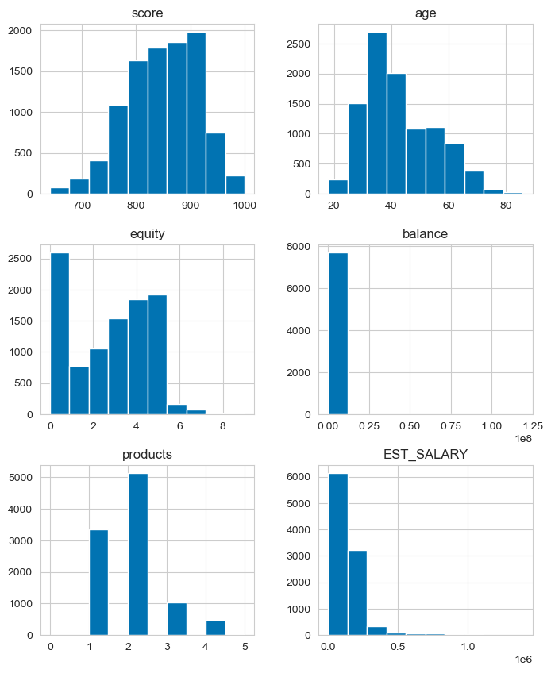

### Посмотрим уникальные значения столбца со строковыми данными:

Чтобы исключить ошибки в написании названиях городов и пола проверим как указаны их названия.

```
['Рыбинск' 'Ярославль' 'Ростов']

Количество уникальных значений: 3
```

```
['Ж' 'М']

Количество уникальных значений: 2
```

В названии городов и пола клиентов ошибок нет. Столбец с названием городов действительно содержит названия трёх городов, которые указаны корректно.

### Вывод этапа знакомства с данными:

Мы провели первичное знакомство с данными. Выяснили, что:

1. Таблица содержит 10 000 строк с информацией о клиентах банка "Метанпромбанк".
2. Некоторые числовые данные содержат выбросы и потребуют обработки.
3. Некоторые столбцы содержат пропуски. Что с ними делать решим на следующем шаге.
4. Так же стоит проверить дубликаты строк и переименовать названия некоторых столбцов.

Первичное знакомство закончено. Перейдём к этапу предобработки.

## Проведём предобработку данных и подготовим их к исследованию.

- Заменим названия столбцов `USERID` и `EST_SALARY`.
- Посмотрим есть ли в данных пропуски. Какого типа пропуски? Можем ли их обработать или оставим как есть?
- Проверим явные дубликаты. Отдельно проверим дубликаты в столбце `USERID` с уникальными ID клиента.
- Изучим аномалии и примем решение по их обработке.
- Создадим столбцы с кодированием городов и пола клиента.
- Получим датасет для исследовательского анализа данных.

### Заменим названия столбцов.

|  | user_id | score | city | gender | age | equity | balance | products | credit_card | last_activity | est_salary | churn |
| --- | --- | --- | --- | --- | --- | --- | --- | --- | --- | --- | --- | --- |
| 1682 | 167595 | 845.0 | Ярославль | Ж | 47.0 | 3 | 395,955.4 | 4 | 0 | 1 | 74,231.6 | 0 |
| 2236 | 178439 | 810.0 | Ярославль | М | 54.0 | 4 | 761,640.3 | 3 | 0 | 1 | 37,346.6 | 1 |
| 5829 | 133082 | 892.0 | Ярославль | М | 37.0 | 5 | 2,442,481.1 | 2 | 1 | 0 | 168,850.3 | 0 |

Названия столбцов заменили корректно.

### Обработаем пропуски.

Из первого этапа мы знаем, что пропуски содержат 2 столбца `age` и `balance`.

#### Пропуски в столбце 'age'.

Пропуски в значениях возраста `age` не зависят от наших текущих данных. Восстановить такие пропуска не получится. Скорее всего, произошёл сбой при выгрузке базы данных.

Проверим сколько таких строк и сколько данных мы потеряем в случае их удаления.

```
Количество строк с пропусками 'age': 26
Потеряем при удалении строк с пропусками 'age': 0.26% данных
```

В случае удаления данных строк мы потеряем небольшое количество данных. Удалим эти строки на следующих шагах. Но сначала проверим пропуска в столбце `balance`.

#### Пропуски в столбце 'balance'.

```
Количество строк с пропусками 'balance': 2295
Потеряем при удалении строк с пропусками 'balance': 22.95% данных
```

- Удалить строки с пропусками `balance` не получится. Слишком много данных потеряем.
- Заменить на 0 мы не можем. Из этапа знакомства с данными мы знаем, что в столбце уже есть значение 0. Значит пропуск в балансе — это не нулевой баланс.

#### Посмотрим, как выглядят строки с этим пропусками 'balance'.

```
Строки с пропусками в столбце 'balance':
```

|  | user_id | score | city | gender | age | equity | balance | products | credit_card | last_activity | est_salary | churn |
| --- | --- | --- | --- | --- | --- | --- | --- | --- | --- | --- | --- | --- |
| 1367 | 143004 | 953.0 | Ярославль | Ж | 33.0 | 0 | NaN | 1 | 1 | 1 | 236,609.3 | 0 |
| 2993 | 207536 | 882.0 | Ярославль | М | 43.0 | 0 | NaN | 1 | 1 | 1 | 293,279.3 | 0 |
| 779 | 212862 | 707.0 | Ярославль | Ж | 28.0 | 0 | NaN | 1 | 1 | 1 | 170,457.4 | 0 |
| 8677 | 171409 | 724.0 | Ярославль | Ж | 63.0 | 0 | NaN | 1 | 1 | 0 | 137,677.7 | 0 |
| 2452 | 180250 | 721.0 | Ярославль | Ж | 40.0 | 0 | NaN | 2 | 1 | 0 | 219,753.6 | 0 |
| 4069 | 139172 | 765.0 | Ярославль | М | 42.0 | 0 | NaN | 1 | 1 | 1 | 662,555.8 | 0 |
| 6642 | 126358 | 930.0 | Ярославль | Ж | 61.0 | 0 | NaN | 2 | 1 | 0 | 88,860.3 | 0 |
| 5913 | 166559 | 906.0 | Рыбинск | М | 48.0 | 0 | NaN | 1 | 1 | 1 | 145,777.7 | 0 |

Визуально выстроить связь пропусков с текущими данными не получилось. Попробуем выстроить связь с текущими данными персонально. Допустим, что пользователи без указания баланса:

- не имеют собственности;
- не имеют кредитной карты;
- имеют аномально низкий или высокий доход;
- так же проверим написали ли такие пользователи заявление об отказе от банковских услуг.

Напишем небольшую функцию.

Проверим:

- имеют ли пользователи с пропусками собственность
- имеют ли пользователи с пропусками кредитные карты
- написали ли пользователи с пропусками заявление о прекращении обслуживания

```
Уникальные значения equity с пропусками в balance:
equity
0    2180
1     114
3       1
Name: count, dtype: int64
```

Видно, что пользователи с пропуском в балансе в большинстве своём имеют нулевой баланс собственности, но есть и другие.

```
Уникальные значения credit_card с пропусками в balance:
credit_card
1    1872
0     423
Name: count, dtype: int64
```

В основном такие пользователи имеют кредитные карты, но есть и без карт.

```
Уникальные значения churn с пропусками в balance:
churn
0    2282
1      13
Name: count, dtype: int64
```

В основном, эти пользователи остаются в банке. Но 13 человек попали в отток.

Посмотрим каким доходом обладают пользователи с пропусками в балансе.

```
Характерные значения 'est_salary' с пропусками в 'balance':
count       2,295.0
mean      226,310.2
std       199,771.8
min        20,274.0
25%       120,347.7
50%       174,160.7
75%       240,015.0
max     1,333,687.4
Name: est_salary, dtype: float64
```

Видно, что у пользователей с пропусками в балансе есть и не высокий доход (20 274) и высокий (1 333 687). Заполнять медианой такие пропуски не корректно.

Таким образом, на данном этапе не удалось выстроить связь пропусков в столбце баланса с текущими данными. Возможно, что пропуски образовались в результате технического сбоя при выгрузке.

Принимаем решение оставить пропуски в столбце баланса и удалим строки с пропусками в столбце с указанием возраста.

#### Удаляем строки с пропусками в столбце 'age'.

```
Количество строк с пропусками 'age': 0
После удаления осталось строк: 9974
```

### Проверим дубликаты.

#### Явные дубликаты.

```
Количество явных дубликатов: 0
```

Явных дубликатов не обнаружено. Проверим есть ли дубликаты в столбце с уникальными ID клиента `user_id`.

#### Неявные дубликаты.

```
Количество дубликатов 'user_id': 50
```

Интересно, что в датафрейме есть дубликаты user_id. Такого быть не должно. Каждый пользователь должен иметь свой уникальный ID. Посмотрим на этих пользователей.

```
Строки с дубликатами 'user_id':
```

|  | user_id | score | city | gender | age | equity | balance | products | credit_card | last_activity | est_salary | churn |
| --- | --- | --- | --- | --- | --- | --- | --- | --- | --- | --- | --- | --- |
| 1893 | 116540 | 883.0 | Рыбинск | Ж | 55.0 | 1 | 362,756.5 | 3 | 0 | 1 | 175,920.5 | 1 |
| 7694 | 116540 | 887.0 | Ярославль | Ж | 38.0 | 0 | NaN | 1 | 0 | 1 | 119,247.6 | 0 |
| 4866 | 117943 | 855.0 | Рыбинск | Ж | 32.0 | 6 | 1,036,832.9 | 4 | 1 | 1 | 107,792.7 | 1 |
| 7542 | 117943 | 880.0 | Ярославль | Ж | 40.0 | 0 | NaN | 1 | 1 | 0 | 137,718.9 | 0 |
| 5863 | 120258 | 908.0 | Рыбинск | Ж | 38.0 | 4 | 2,213,581.6 | 2 | 0 | 1 | 160,327.8 | 1 |
| 5896 | 120258 | 905.0 | Ярославль | М | 30.0 | 0 | NaN | 1 | 1 | 1 | 146,428.0 | 0 |
| 1411 | 123461 | 829.0 | Ярославль | Ж | 59.0 | 0 | 96,222.4 | 2 | 0 | 1 | 102,771.6 | 1 |
| 8638 | 123461 | 934.0 | Рыбинск | М | 34.0 | 0 | NaN | 2 | 1 | 0 | 291,619.3 | 0 |
| 9775 | 124450 | 758.0 | Рыбинск | Ж | 36.0 | 0 | 73,574.1 | 2 | 0 | 1 | 79,963.6 | 0 |
| 8164 | 124450 | 859.0 | Ярославль | Ж | 38.0 | 6 | 516,811.2 | 1 | 1 | 1 | 95,144.6 | 1 |
| 4850 | 126368 | 909.0 | Ярославль | Ж | 30.0 | 4 | 1,322,623.3 | 2 | 0 | 1 | 140,675.7 | 1 |
| 5420 | 126368 | 832.0 | Рыбинск | Ж | 33.0 | 0 | NaN | 1 | 0 | 0 | 118,465.3 | 0 |

Визуально видно, что за дублями в user_id кроются разные пользователи. Проверим во всех ли строчках разные значения пола, возраста, города.

```
Строки с дубликатами 'user_id', 'age', 'gender', 'city': 0
```

Для задачи нам важны уникальные пользователи, поэтому мы оставим эти дубли в `user_id`. Тем более, что значения из этого столбца мы не будем использовать в исследовании.

Проверим почему могли образоваться такие дубли. Есть версия, что задвоились строки при выгрузке у двух городов. Ярославля и Рыбинска.

```
city
Рыбинск      50
Ярославль    50
Name: count, dtype: int64
```

Видно, что дубли распределилсь ровно между Рыбинском и Ярославлем 50/50. Скорее всего, был технический сбой, и 50 строк Рыбинска скопировали user_id у 50 строк Ярославля. Или наоброт.

### Проверка аномальных значений.

#### Посмотрим аномалию в столбце products.

Из условия мы знаем, что у пользователей не может быть 0 продуктов. Проверим есть ли пользователи у которых `products` = 0

|  | user_id | score | city | gender | age | equity | balance | products | credit_card | last_activity | est_salary | churn |
| --- | --- | --- | --- | --- | --- | --- | --- | --- | --- | --- | --- | --- |
| 8957 | 147837 | 962.0 | Рыбинск | Ж | 79.0 | 3 | NaN | 0 | 0 | 0 | 25,064.0 | 1 |

Есть всего одна строка, где у пользователя нет продуктов. Удалим её.

```
Осталось строк: 9973
```

#### Проверим и отсечём аномальные значения других столбцов:

На этапе предварительного знакомства с даными нас заинтересовали 3 столбца:

- `age` — возраст клиента;
- `balance` - баланс на счёте;
- `est_salary` - оценочный доход.

Построим диаграммы размаха и посмотрим как выглядят данные этих столбцов. Создадим небольшую функцию.

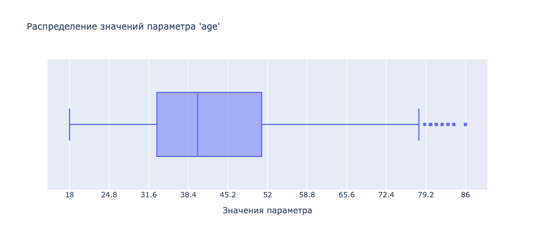

Пользователей со значением возраста после 78 не так много. Можно принять за аномальное значение и удалить эти строки в конце этого параграфа.

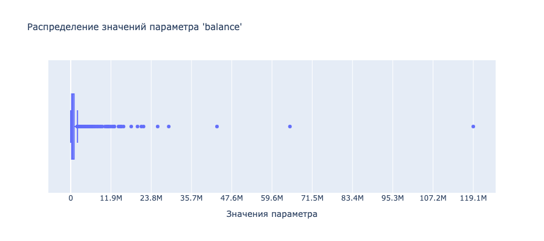

Видно, что выбросов очень много. Самого ящика даже не видно. Не хочется удлять все значения. Выберем аномалии до отметки 13,200,000

Примем эти выбросы за аномально высокие значения.

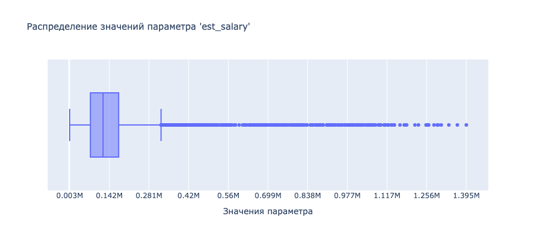

Много выбросов, которые сливаются в длинную линию на графике. Отсечём только явные одиночные точки до значения 1,240,000.

Посчитаем сколько данных мы потеряем при удалении всех аномалий.

```
Количество строк в датафрейме до удаления аномалий: 9973
Количество строк в датафрейме после удаления аномалий: 9921
Потеряли при удалении аномалий: 0.52% данных
```

Мы потеряли небольшое число данных при удалении аномальных значений. Двинемся дальше.

### Добавим столбцы с кодированием городов и пола клиента.

Для кодирования городов применим метод `pd.get_dummies()`.

По умолчанию он удаляет исходный столбец, заменяя его закодированными. Воспользуемся параметром `drop_first=False`, чтобы сохранить исходный столбец.

Так же переименуем названия столбцов на более привычные.

#### Кодирование названий городов.

|  | index | user_id | score | gender | age | equity | balance | products | credit_card | last_activity | est_salary | churn | city_original | city_Ростов | city_Рыбинск | city_Ярославль |
| --- | --- | --- | --- | --- | --- | --- | --- | --- | --- | --- | --- | --- | --- | --- | --- | --- |
| 6774 | 6812 | 146712 | 867.0 | Ж | 39.0 | 2 | 2,758,303.9 | 2 | 0 | 1 | 301,241.6 | 1 | Ярославль | False | False | True |
| 3002 | 3024 | 208650 | 846.0 | М | 45.0 | 2 | 408,890.9 | 2 | 1 | 0 | 198,606.8 | 0 | Рыбинск | False | True | False |
| 9073 | 9136 | 140672 | 809.0 | М | 49.0 | 2 | 408,193.5 | 1 | 0 | 0 | 128,721.6 | 0 | Рыбинск | False | True | False |

Кодирование прошло успешно. Приведём датафейм к красивому виду. Переименуем столбцы и вернём их на привычное место после столбца `score`.

|  | index | user_id | city | rostov | rybinsk | yaroslavl | score | gender | age | equity | balance | products | credit_card | last_activity | est_salary | churn |
| --- | --- | --- | --- | --- | --- | --- | --- | --- | --- | --- | --- | --- | --- | --- | --- | --- |
| 9582 | 9657 | 163252 | Рыбинск | False | True | False | 900.0 | Ж | 52.0 | 5 | 1,079,859.8 | 2 | 0 | 0 | 101,663.4 | 0 |
| 6137 | 6174 | 146640 | Ярославль | False | False | True | 777.0 | Ж | 63.0 | 5 | 1,492,185.2 | 3 | 1 | 0 | 42,238.2 | 0 |
| 4786 | 4816 | 154828 | Рыбинск | False | True | False | 818.0 | Ж | 36.0 | 4 | 512,578.9 | 2 | 1 | 1 | 93,222.1 | 0 |

Отлично. Столбцы на привычных местах.

#### Кодирование пола клиентов.

|  | index | user_id | city | rostov | rybinsk | yaroslavl | score | gender | male | female | age | equity | balance | products | credit_card | last_activity | est_salary | churn |
| --- | --- | --- | --- | --- | --- | --- | --- | --- | --- | --- | --- | --- | --- | --- | --- | --- | --- | --- |
| 1129 | 1138 | 224924 | Ростов | True | False | False | 929.0 | Ж | False | True | 69.0 | 0 | NaN | 1 | 0 | 0 | 120,476.4 | 0 |
| 4210 | 4235 | 183816 | Ярославль | False | False | True | 787.0 | Ж | False | True | 41.0 | 3 | 476,498.3 | 2 | 1 | 0 | 170,915.2 | 0 |
| 2756 | 2777 | 149868 | Рыбинск | False | True | False | 897.0 | М | True | False | 32.0 | 3 | 259,806.8 | 2 | 1 | 0 | 83,967.9 | 0 |

Категорирование переменных прошло успешно.

### Изменим тип данных.

Посмотрим как сейчас выглядят данные.

```
<class 'pandas.core.frame.DataFrame'>
RangeIndex: 9921 entries, 0 to 9920
Data columns (total 18 columns):
 #   Column         Non-Null Count  Dtype
---  ------         --------------  -----
 0   index          9921 non-null   int64
 1   user_id        9921 non-null   int64
 2   city           9921 non-null   object
 3   rostov         9921 non-null   bool
 4   rybinsk        9921 non-null   bool
 5   yaroslavl      9921 non-null   bool
 6   score          9921 non-null   float64
 7   gender         9921 non-null   object
 8   male           9921 non-null   bool
 9   female         9921 non-null   bool
 10  age            9921 non-null   float64
 11  equity         9921 non-null   int64
 12  balance        7657 non-null   float64
 13  products       9921 non-null   int64
 14  credit_card    9921 non-null   int64
 15  last_activity  9921 non-null   int64
 16  est_salary     9921 non-null   float64
 17  churn          9921 non-null   int64
dtypes: bool(5), float64(4), int64(7), object(2)
memory usage: 1.0+ MB
```

```
<class 'pandas.core.frame.DataFrame'>
RangeIndex: 9921 entries, 0 to 9920
Data columns (total 18 columns):
 #   Column         Non-Null Count  Dtype
---  ------         --------------  -----
 0   index          9921 non-null   int64
 1   user_id        9921 non-null   int64
 2   city           9921 non-null   category
 3   rostov         9921 non-null   bool
 4   rybinsk        9921 non-null   bool
 5   yaroslavl      9921 non-null   bool
 6   score          9921 non-null   int64
 7   gender         9921 non-null   category
 8   male           9921 non-null   bool
 9   female         9921 non-null   bool
 10  age            9921 non-null   int64
 11  equity         9921 non-null   int64
 12  balance        7657 non-null   float64
 13  products       9921 non-null   int64
 14  credit_card    9921 non-null   int64
 15  last_activity  9921 non-null   int64
 16  est_salary     9921 non-null   float64
 17  churn          9921 non-null   int64
dtypes: bool(5), category(2), float64(2), int64(9)
memory usage: 920.8 KB
```

Типы данных заменили.

### Получим датасет для исследовательского анализа данных.

```
Количество строк в датасете после предобработки: 9921
```

|  | user_id | city | rostov | rybinsk | yaroslavl | score | gender | male | female | age | equity | balance | products | credit_card | last_activity | est_salary | churn |
| --- | --- | --- | --- | --- | --- | --- | --- | --- | --- | --- | --- | --- | --- | --- | --- | --- | --- |
| 0 | 183012 | Рыбинск | False | True | False | 850 | Ж | False | True | 25 | 1 | 59,214.8 | 2 | 0 | 1 | 75,719.1 | 1 |
| 1 | 146556 | Рыбинск | False | True | False | 861 | Ж | False | True | 37 | 5 | 850,594.3 | 3 | 1 | 0 | 86,621.8 | 0 |
| 2 | 120722 | Рыбинск | False | True | False | 892 | Ж | False | True | 30 | 0 | NaN | 1 | 1 | 1 | 107,683.3 | 0 |
| 3 | 225363 | Ярославль | False | False | True | 866 | Ж | False | True | 51 | 5 | 1,524,746.3 | 2 | 0 | 1 | 174,423.5 | 1 |
| 4 | 157978 | Ярославль | False | False | True | 730 | М | True | False | 34 | 5 | 174.0 | 1 | 1 | 0 | 67,353.2 | 1 |
| ... | ... | ... | ... | ... | ... | ... | ... | ... | ... | ... | ... | ... | ... | ... | ... | ... | ... |
| 9916 | 120553 | Рыбинск | False | True | False | 814 | М | True | False | 27 | 1 | 78,144.6 | 1 | 0 | 1 | 18,943.6 | 0 |
| 9917 | 139170 | Ярославль | False | False | True | 894 | М | True | False | 46 | 0 | NaN | 1 | 1 | 0 | 196,898.3 | 0 |
| 9918 | 115639 | Ярославль | False | False | True | 903 | М | True | False | 24 | 0 | NaN | 2 | 1 | 1 | 108,905.1 | 0 |
| 9919 | 148700 | Ярославль | False | False | True | 777 | Ж | False | True | 68 | 3 | 865,458.0 | 3 | 0 | 1 | 86,874.9 | 0 |
| 9920 | 96267 | Рыбинск | False | True | False | 828 | Ж | False | True | 58 | 3 | 1,180,886.7 | 4 | 0 | 1 | 21,422.4 | 0 |

9921 rows × 17 columns

## Проведём исследовательский анализ данных.

- Определим какую долю составляют клиенты оттока от всей базы клиентов. Это будет уровень оттока банка.
- Изучим перечисленные ниже признаки клиентов банка и построим графики для каждого из этих признаков. Важно изучить как признаки распределены:
  - для всей базы в целом;
  - для "отточной" части базы в частности.
- **Список признаков:**
  - баллы кредитного скоринга `score`,
  - город `city`,
  - пол `gender`,
  - возраст `age`,
  - количество баллов собственности `equity`,
  - баланс на счёте `balance`,
  - количество продуктов клиента `products`,
  - наличие кредитной карты у клиента `credit_card`,
  - активность клиента за последние 30 дней `last_activity`,
  - оценочный дохода клиента `EST_SALARY`.
- Выделим клиентов:
  - у которых уровень оттока выше уровня оттока в целом по банку (для категориальных/дискретных признаков).
  - которые составляют наибольший объём оттока (для непрерывных признаков).
- Определим признаки, которые больше всего влияют на отток клиента. Проведём корреляционный анализ признака `сhurn` с другими признаками.

### Какую долю составляет отток.

Посчитаем какое количество пользователей попало в отток, а сколько осталось. Выведем уровень оттока банка на круговой диаграмме для презентации.

[figure not shown]

Посчитаем уровень оттока

```
Уровень оттока банка: 18.26%
Всего в оттоке: 1812 клиентов
```

Получилось, что 18,2% это уровень оттока клиентов банка на сегодняшний день. Всего написали заявление 1 812 клиентов.

### Изучим признаки клиентов банка.

Посмотрим как признаки распределены:

- для всей базы в целом;
- для "отточной" части базы в частности.

Для начала подготовим срез отточных клиентов. У таких клиентов в столбце `churn` стоит значение 1.

```
Количество клиентов в оттоке: 1812
```

|  | user_id | city | rostov | rybinsk | yaroslavl | score | gender | male | female | age | equity | balance | products | credit_card | last_activity | est_salary | churn |
| --- | --- | --- | --- | --- | --- | --- | --- | --- | --- | --- | --- | --- | --- | --- | --- | --- | --- |
| 0 | 183012 | Рыбинск | False | True | False | 850 | Ж | False | True | 25 | 1 | 59,214.8 | 2 | 0 | 1 | 75,719.1 | 1 |
| 3 | 225363 | Ярославль | False | False | True | 866 | Ж | False | True | 51 | 5 | 1,524,746.3 | 2 | 0 | 1 | 174,423.5 | 1 |
| 4 | 157978 | Ярославль | False | False | True | 730 | М | True | False | 34 | 5 | 174.0 | 1 | 1 | 0 | 67,353.2 | 1 |

Всё верно. Датафрем по клиентам оттока готов.

#### Подотовим функции для вывода графиков.

Ясно, что в общем датафрейме и датафрейме оттока данные с разными количествами наблюдений.

При построении гистограм нам потребуется параметр `Плотность вероятности распределения`. Этот параметр позволит адекватно сравнить распределения двух наборов данных с разными размерами. Он нормализует частоты появления значений в диапазоне (бин). В Plotly используем параметр `histnorm='probability density'`.

Гистограмма покажет не абсолютные частоты значений, а плотность вероятности. То есть, мы увидим относительную вероятность попадания данных в этот бин.

Напишем функцию, которую потом будем использовать.

Для категорийных типов данных напишем функцию, которая построит две круговых диаграммы рядом.

Пройдём датафрейм по всем столбцам с параметрами. По очереди слева направо.

#### Распределение клиентов по баллам кредитного скоринга.

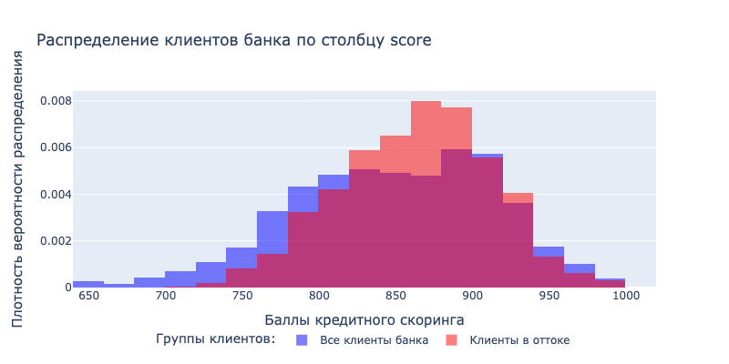

- Большинство клиентов в общей базе имеют рейтинг от 760 до 939 баллов.Это видно по графику синего цвета.
- Видно, что относительная вероятность попадания клиента в отток начинается со значений от 820 до 899 баллов кредитного скоринга. Именно в этом диапазоне красный график поднимается над синим.

#### Распределение клиентов по городам.

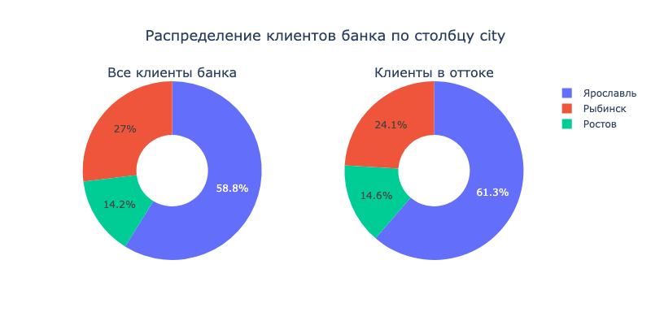

- Ожидаемо, что распределение по городам в основной базе связано с количеством населения города. Больше всех в базе клиентов из Ярославля, потом из Рыбинска, потом из Ростова.
- Нельзя сказать, что распределение базы оттока сильно отличается от распредления основной базы. В Ростове разницы вообще нет.

#### Распределение клиентов по полу.

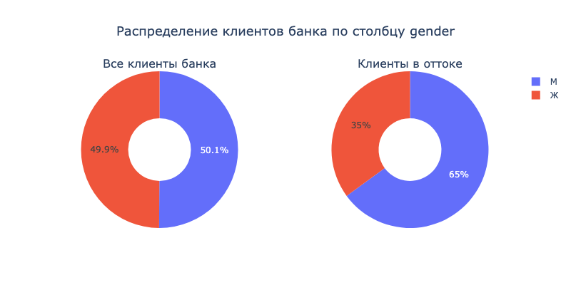

- Видно, что в целом распредление мужчин и женщин в общей базе одинаковое.
- При этом, мужчин в оттоке больше почти в 2 раза, чем женщин. Скорее всего, у мужчин уровень оттока выше, чем в целом по базе. Проверим это в следующих шагах.

#### Распределение клиентов по возрасту.

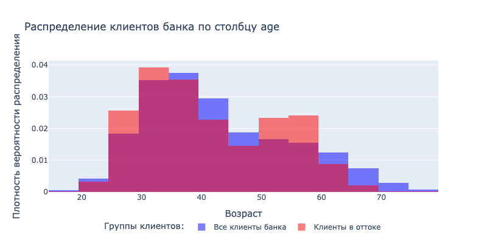

- Основное распредление клиентов по базе стремится к нормальному распределению. Основной возраст от 30 до 44 лет.
- В оттоке распредление немного другое. Основные данные распределены в диапазоне от 25 до 39 и виден яркий подъём в возрастной группе 50-59.
- Интересное наблюдение по группе 50 - 59. Разберём дальше, что побудило клиентов этого возраста написать заявление об уходе из банка.

#### Распределение клиентов по количеству баллов собственности.

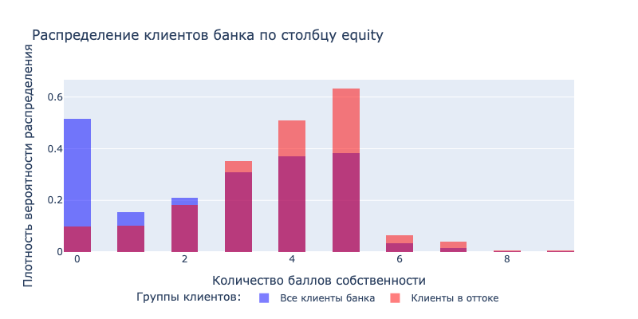

- В целом по базе клиентов преобладают клиенты с отстуствием баллов собственности.
- Интересно, что чем больше собственности, тем выше вероятность оттока. Максимум склонны к оттоку клиенты с баллом - 5. При этом видно, что клиенты с нулевым балансом почти не попали в отток.

Такое впечатление, что банк хорошо умеет выдавать кредиты на первые крупные покупки (например, на покупку квартиры). Но банку нечего предложить клиентам, у которых достаточное число собственности и им не требуется кредит на покупку недвижимости или авто.

#### Распределение клиентов по балансу счёта.

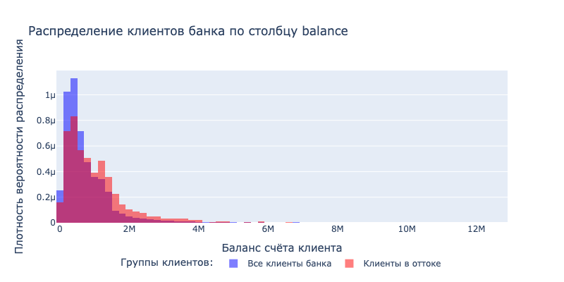

Все данные сместились влево. Посмотрим левую часть графика поближе.

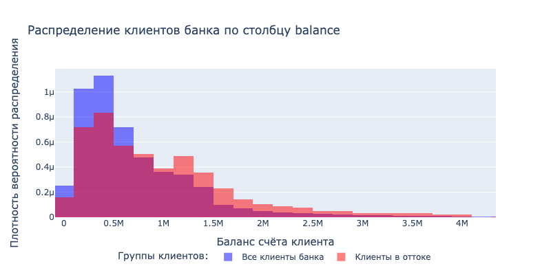

- основое количество клиентов сосредоточено в диапазоне баланса от 100 000 до 500 000
- в базе оттока данные схожи, но границе баланса от 900 000 и выше клиентов оттока больше.

Можно предположить, что банк не может ничего предложить клиентам с большим балансом счёта. Пока складывается ощущение, что банк нацелен на аудиторию, которая берёт кредиты, но не может предложить вклады или накопительное страхование. Посмотрим дальше.

#### Распределение клиентов по количеству продуктов.

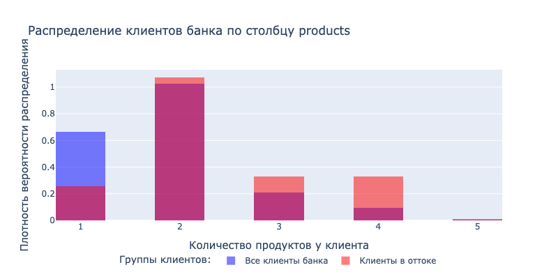

- На синем графике распределения общей базы видно, что у клиентов в основном либо 1, либо 2 продукта.
- У клиентов из оттока тоже в основном 2 продукта, но вот с 1 продуктом их гораздом меньше.
- Видно, что клиенты с 3 и 4 продуктами уходят в отток. Возможно, банк не обновляет линейку продуктов?

#### Распределение клиентов по наличию кредитной карты.

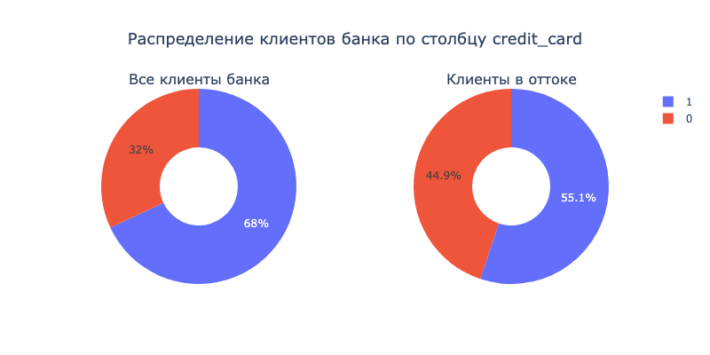

Возможно, действительно, банк хорошо работает с кредитными продуктами, но не так хорошо работает с вкладами или страхованием и тд.

#### Распределение клиентов по активности.

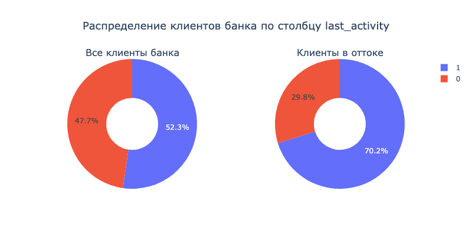

- По активности в основной базе клиенты распределелись примерно поровну.
- При этом, в оттоке бОльшую долю составляют активные клиенты.

#### Распределение клиентов по уровню дохода.

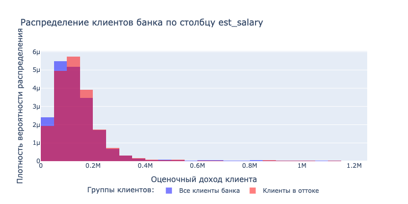

- В основном в банке обслуживаются клиенты с уровнем дохода от 50 000 до 150 000.
- Клиенты оттока в целом повторяют это распределение, но в группе от 100 000 до 200 000 их больше.

### Выделим клиентов:

Нам интересны клиенты, которых:

- уровень оттока выше уровня оттока в целом по банку (для категориальных/дискретных признаков).
- которые составляют наибольший объём оттока (для непрерывных признаков).
1. **Для непрерывных признаков и выделения наибольшего объёма** нам досточно гистограмм выше. Там хорошо видны участки красного цвета, которые выделяются над синим графиком.
2. **Но для категориальных/ дискретных признаков** нам нужно построить новые круговые диаграммы, которые наглядно покажут доли оттока в общей базе.

#### Уровень оттока по каждому городу `rostov`, `rybinsk`, `yaroslavl`.

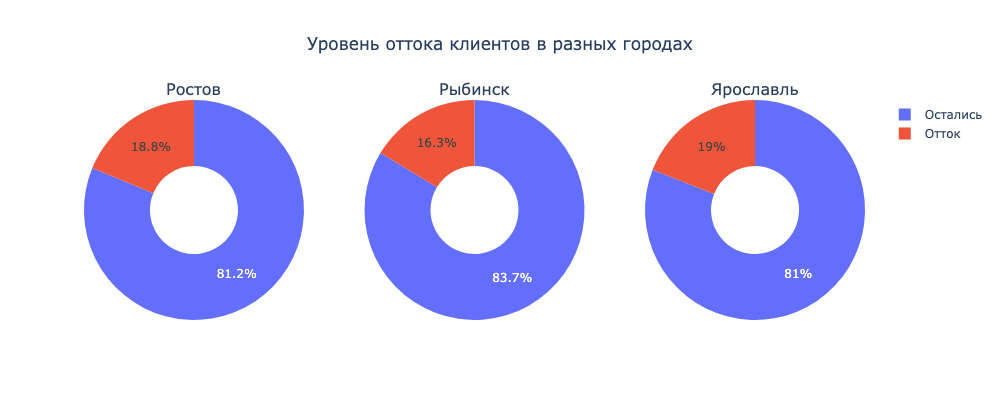

Уровни оттока каждого города меньше или незначительно выше, чем уровень оттока по банку. Ни один город не влияет на отток.

#### Уровень оттока среди мужчин и женщин `male`, `female`.

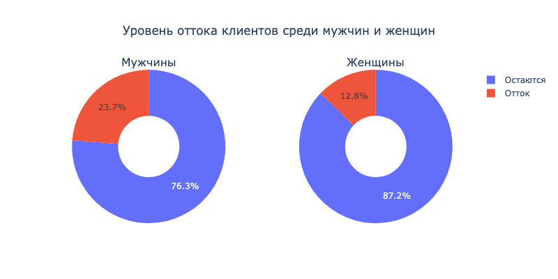

У мужчин, как и предполагали, уровень оттока выше, чем в целом по банку.

Дальше проверим уровень оттока по параметрам `credit_card` и`last_activity`. Напишем функцию для этих двух параметров.

#### Уровень оттока по параметру `credit_card`.

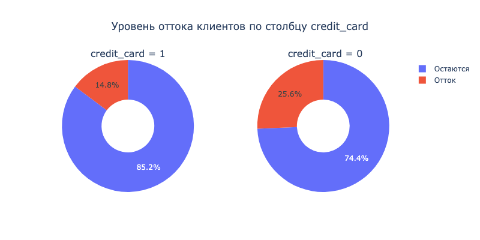

Уровень оттока среди тех, у кого нет кредитной карты выше, чем уровень по всей базе.

#### Уровень оттока по параметру `last_activity`.

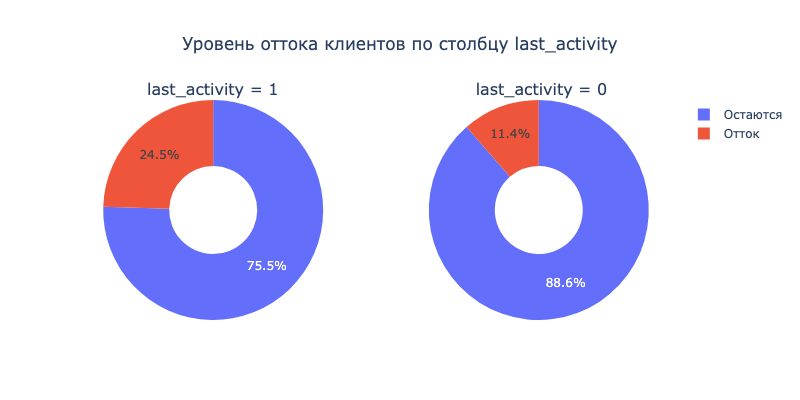

У активных клиентов уровень оттока выше, чем уровень всей базы.

### Корреляционный анализ признака `сhurn` с другими признаками.

#### Корреляция Пирсона.

Выведем матрицу корреляций для столбца `churn`.

```
Корреляция признаков оттока клиентов:

churn            1.0
products         0.3
equity           0.3
balance          0.2
last_activity    0.2
male             0.1
score            0.1
yaroslavl        0.0
rostov           0.0
est_salary       0.0
rybinsk         -0.0
age             -0.0
credit_card     -0.1
female          -0.1
Name: churn, dtype: float64
```

- `products` - количество продуктов,
- `equity` - баллы собственности,
- `balance`- баланс
- `last_activity` - активность клиента
- `male` - клиент-мужчина.

### Выводы исследовательского этапа.

1. База клиентов банка выглядит так:
- `score` - баллы кредитного рейтинга от 760 до 939 баллов;
- `city` - преимущественно клиент из Ярославля, потому город самый большой по населению;
- `gender` - пол - мужчина / женщина в равной пропорции;
- `age` - возраст от 30 до 44;
- `equity` - баллов собственности - преимущественно 0;
- `balance` - баланс счёта - от 100 до 500 тыс.;
- `products` - продуктов 1 или 2;
- `credit_card` - есть кредитная карта;
- `last_activity` - одинаковая активность за последние 30 дней;
- `est_salary` оценочный доход клиента от 50 000 до 150 000.
2. Базу оттока сформировал клиент:
- `score` - баллы кредитного рейтинга от 820 до 899;
- `city` - не влияет на отток;
- `gender` - пол - мужчина;
- `age` - возраст от 25 до 39 или от 50 до 59;
- `equity` - баллов собственности - от 3 до 9 включительно, с пиком на 5 баллах;
- `balance` - баланс счёта - от 700 тыс. и выше, с пиками 1,1 до 1,69 млн.;
- `products` - продуктов от 2 и выше, с пиком на 4 продуктах;
- `credit_card` - нет кредитной карты;
- `last_activity` - у клиента была активность за последние 30 дней;
- `est_salary` оценочный доход клиента от 100 000 до 300 000, с яркими пиками от 100 000 до 200 000.
3. Влияние всех признаков на параметр оттока `churn`не сильное.
4. Корреляция по методу Пирсона выделяет основные признаки влияния:
- `products` - количество продуктов,
- `equity` - баллы собственности,
- `balance`- баланс,
- `last_activity` - активность клиента,
- `male` - клиент-мужчина.

## Сформулируем и проверим статистические гипотезы.

- Проверим гипотезу различия дохода между теми клиентами, которые ушли и теми, которые остались.
- Сформулируем и проверим ещё одну или несколько статистических гипотез на основе выводов исследовательского анализа.

### Гипотеза №1

Проверим гипотезу о различии дохода `est_salary` между клиентами, которые ушли `churn=1` и теми, которые остались `churn=0`. Подготовим два массива данных.

Выбор метода теста зависит от распределения данных, их дисперсий и природы выборок. Методика выбора следующая:

- Данные нормальные + равные дисперсии - t-тест.
- Данные нормальные + неравные дисперсии - t-тест Уэлча.
- Данные не нормальные - тест Манна-Уитни.

#### Проверим данные на нормальность распределения методом Шапиро-Уилка.

```
p-значение:(churn=1): 0.0
Распределение не является нормальным
```

```
p-значение:(churn=0): 0.0
Распределение не является нормальным
```

В случае, если распределение не является нормальным применяется стат. метод тест Манна-Уитни.

#### Проверим гипотезу №1 с помощью теста Манна-Уитни.

Сформулируем нулевую и альтернативную гипотезы перед проведением теста:

- Н_0: доход клиентов, которые ушли равен доходу клиентов, которые остались.
- Н_1: доход клиентов, которые ушли не равен доходу клиентов, которые остались.

```
p-значение: 0.0002650889580565624
Отвергаем нулевую гипотезу. Доход клиентов оттока не равен доходу оставшихся.
```

p-значение значительно меньше 0.05. Мы отвергаем нулевую теорию. Это значит, что доход клиентов, которые ушли **не равен доходу** клиентов, которые остались.

### Гипотеза №2

Проверим гипотезу о разнице в среднем возрасте клиентов, у которых есть кредитная карта и у тех, у которых её нет.

Проверим данные на нормальность распределения.

```
p-значение:(churn=1): 1.0058940766462834e-40
Распределение не является нормальным
```

```
p-значение:(churn=1): 1.9963582750399616e-26
Распределение не является нормальным
```

Распределение не является нормальным. Примениим тест Манна-Уитни.

#### Проверим гипотезу №2 с помощью теста Манна-Уитни.

Сформулируем нулевую и альтернативную гипотезы перед проведением теста:

- Н-0: средний возраст клиентов с кредитной картой равен возрасту клиентов без карты.
- Н_1: средний возраст клиентов с кредитной картой не равен возрасту клиентов без карты.

```
p-значение: 3.2325392988288344e-32
Отвергаем нулевую гипотезу. Возраст клиентов с картой не равен возрасту клиентов с картой.
```

p-значение значительно меньше уровня стат. значимости 0.05. Мы отвергаем нулевую теорию. Это значит, что средний возраст клиентов без карты **не равен среднему возрасту** клиентов с кредитной картой.

### Выводы этапа проверки гипотез.

1. Доход клиентов, которые ушли **не равен доходу клиентов**, которые остались.
2. Средний возраст клиентов без карты **не равен среднему возрасту** клиентов с кредитной картой.

## Напишем промежуточные выводы.

- Какие признаки сильнее всего влияют на отток клиентов? Можем ли объединить несколько признаков в комбинации для будущих сегментов?
1. По результатам исследований выделим факторы, которые сильнее повлияют на отток. Предварительно объеденим их.
2. **Версия 1. Клиенты с хорошим балансом, доходом и собственностью.**
- `equity` - баллов собственности - от 3 до 9 включительно, с пиком на 5 баллах;
- `balance` - баланс счёта - от 700 тыс. и выше, с пиками 1,1 до 1,69 млн.;
- `est_salary` оценочный доход клиента от 100 000 до 300 000, с яркими пиками от 100 000 до 200 000.
3. **Версия 2. Клиенты без кредитной карты, но с активностью по счёту.**
- `credit_card` - нет кредитной карты;
- `last_activity` - у клиента была активность за последние 30 дней;
4. **Версия 3. Клиенты с большим числом продуктов и баллами кредитного рейтинга.**
- `products` - продуктов от 2 и выше, с пиком на 4 продуктах;
- `score` - баллы кредитного рейтинга от 820 до 899;
5. Как объединить гендерные и возрастные признаки решим на этапе сегментирования:
- `age` - возраст
  - от 25 до 39
  - от 50 до 59;
- `gender` - пол - мужчина;
6. Признак `city` мы исключаем из среза. Он не сильно повлияет на сегменты.

## Сегментируем пользователей.

- Объединим признаки оттока и сформируем из них сегменты. Сегмент должен содержать не менее 2-ух признаков.
- Отберём для отдела маркетинга не менее 2-ух релевантных сегментов. Показатели релевантности:
  - объём выборки не менее 7-8% от общей базы клиентов,
  - уровень оттока сегмента должен быть выше, чем уровень оттока в целом по банку.

Напишем функцию, которая будет принимать срезы данных и считать по ним объёмы сегментов и уровень оттока.

```
Сегмент 1:
Условие отбора: equity >= 3 and balance > 700000 and 100000 <= est_salary <= 300000
Общее количество клиентов: 1630
Количество клиентов оттока: 657
Уровень оттока: 40.31%
```

|  | user_id | city | rostov | rybinsk | yaroslavl | score | gender | male | female | age | equity | balance | products | credit_card | last_activity | est_salary | churn |
| --- | --- | --- | --- | --- | --- | --- | --- | --- | --- | --- | --- | --- | --- | --- | --- | --- | --- |
| 1221 | 156743 | Рыбинск | False | True | False | 827 | Ж | False | True | 44 | 5 | 958,410.7 | 2 | 1 | 1 | 108,096.9 | 0 |
| 9795 | 202216 | Ростов | True | False | False | 815 | М | True | False | 37 | 4 | 774,314.9 | 2 | 0 | 1 | 211,488.4 | 0 |
| 3460 | 182057 | Ярославль | False | False | True | 956 | М | True | False | 24 | 5 | 3,526,327.9 | 2 | 1 | 0 | 237,788.4 | 0 |
| 6654 | 175371 | Ярославль | False | False | True | 878 | Ж | False | True | 59 | 4 | 1,430,131.2 | 1 | 1 | 0 | 102,597.5 | 0 |
| 1634 | 122200 | Ярославль | False | False | True | 890 | Ж | False | True | 45 | 4 | 2,061,863.3 | 2 | 1 | 0 | 249,724.8 | 0 |

```
Сегмент 2:
Условие отбора: credit_card == 0 and last_activity == 1 and age >= 25 and age <= 39
Общее количество клиентов: 712
Количество клиентов оттока: 317
Уровень оттока: 44.52%
```

|  | user_id | city | rostov | rybinsk | yaroslavl | score | gender | male | female | age | equity | balance | products | credit_card | last_activity | est_salary | churn |
| --- | --- | --- | --- | --- | --- | --- | --- | --- | --- | --- | --- | --- | --- | --- | --- | --- | --- |
| 8876 | 215126 | Ярославль | False | False | True | 914 | М | True | False | 39 | 4 | 7,004,446.6 | 3 | 0 | 1 | 891,360.4 | 0 |
| 3903 | 148259 | Ярославль | False | False | True | 771 | Ж | False | True | 36 | 2 | 135,490.5 | 3 | 0 | 1 | 62,552.3 | 0 |
| 4967 | 217933 | Рыбинск | False | True | False | 909 | М | True | False | 34 | 4 | 2,183,075.5 | 2 | 0 | 1 | 242,999.8 | 1 |
| 8270 | 148825 | Рыбинск | False | True | False | 759 | М | True | False | 32 | 3 | 345,610.2 | 2 | 0 | 1 | 63,784.0 | 0 |
| 6938 | 126441 | Ярославль | False | False | True | 883 | М | True | False | 36 | 0 | NaN | 1 | 0 | 1 | 185,748.5 | 0 |

```
Сегмент 3:
Условие отбора: age >= 50 and age <= 59 and products >= 2
Общее количество клиентов: 1133
Количество клиентов оттока: 383
Уровень оттока: 33.80%
```

|  | user_id | city | rostov | rybinsk | yaroslavl | score | gender | male | female | age | equity | balance | products | credit_card | last_activity | est_salary | churn |
| --- | --- | --- | --- | --- | --- | --- | --- | --- | --- | --- | --- | --- | --- | --- | --- | --- | --- |
| 4803 | 156900 | Ярославль | False | False | True | 768 | Ж | False | True | 58 | 3 | 285,660.1 | 2 | 1 | 0 | 113,178.3 | 0 |
| 5011 | 207110 | Рыбинск | False | True | False | 898 | М | True | False | 51 | 3 | 643,386.9 | 2 | 0 | 1 | 130,428.3 | 1 |
| 1473 | 127627 | Ярославль | False | False | True | 859 | Ж | False | True | 56 | 3 | 378,077.8 | 2 | 1 | 0 | 56,026.0 | 0 |
| 7006 | 139950 | Ростов | True | False | False | 811 | М | True | False | 58 | 5 | 423,518.4 | 2 | 1 | 1 | 74,538.5 | 0 |
| 5062 | 150247 | Рыбинск | False | True | False | 896 | Ж | False | True | 55 | 4 | 1,858,499.1 | 4 | 1 | 1 | 98,974.9 | 1 |

Построим стековый барплот, где отобразим 3 сегмента с отображением общего количества клиентов и клиентов оттока. Подготовим данные. Сделаем списки с данными по которым построим барплот.

- общее количество клиентов
- количество клиентов оттока
- количество оставшихся клиентов
- уровень оттока

Построим график по спискам значений.

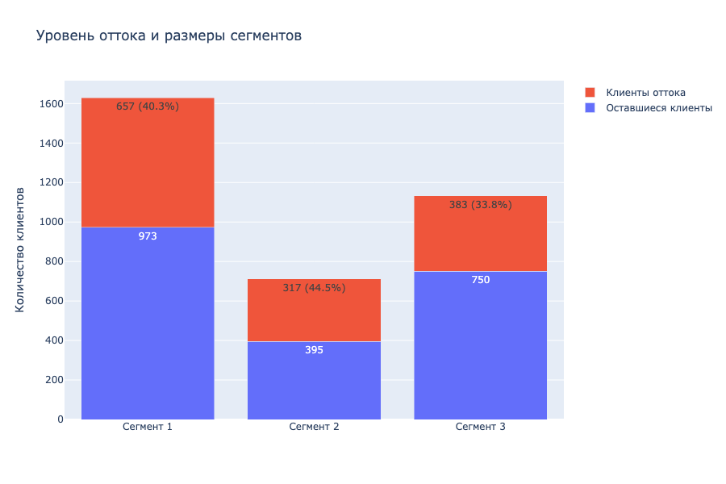

### Выводы этапа сегментирования.

1. Подобрали 3 сегмента по условиям:
- объём выборки не менее 7-8% от общей базы клиентов,
- уровень оттока сегмента должен быть выше, чем уровень оттока в целом по банку.
2. Опишем рекомендации по работе с сегментами на этапе общего вывода.

## Напишем общий вывод и рекомендации.

- Опишем полученные результаты и зафиксируем итоговые сегменты.
- Дадим рекомендации для отдела маркетинга.
1. Мы провели анализ данных о 9 921 клиенте "Метанпромбанка".
2. На сегодняшний день 1 812 клиентов написали заявление об уходе из банка. Это составляет 18,3% от общей базы.
3. Основной задачей проекта было:
- проанализировать пользователей банковских услуг,
- выделить сегменты клиентов, которые склонны уйти из банка,
- дать конкретные рекомендации по сегментам.
4. **Сегмент 1**
- `equity` - баллов собственности - от 3 и выше;
- `balance` - баланс счёта - от 700 тыс. и выше;
- `est_salary` оценочный доход клиента от 100 000 до 300 000.

У клиентов этого сегмента есть доход, собственность и баланс счёта. Ему не интересно предложение кредитного продукта, но ему стоит предложить инвестиционный продукт (например, вклад) или продукт накопительного страхования.

5. **Сегмент 2**
- `credit_card` - нет кредитной карты;
- `last_activity` - у клиента была активность за последние 30 дней;
- `age` - возраст от 25 до 39.

Это клиенты молодого и среднего возраста. У них есть движения по счёту, значит они активно пользуются приложением или услугами банка. При этом, у них нет кредитной карты. Логично предложить добавить в своё приложение красивую кредитную карта банка с выгодными условиями. Либо предложить кэшбек за активное пользование услугами.

6. **Сегмент 3**
- `products` - продуктов от 2 и выше, с пиком на 4 продуктах;
- `age` - возраст от 50 до 59.

Клиенты в возрасте от 50 до 59 лет, у которых много продуктов банка. Если клиенты закрывают свои счёта, то скорее всего, у них есть более выгодные предложения от других банков. Им стоит предложить повышенную ставку по вкладам или более выгодные условия по другим продуктам.

## Подготовим презентацию.

- Выберем важные тезисы и наблюдения по сегментам, которые могут заинтересовать заказчика.
- Подготовим презентацию результатов исследования для отдела маркетинга.

[Скачать презентацию](https://disk.yandex.ru/i/x-stMFThUcr2jg);